# Pitch

Declan Oberlies

2026-02-24

For my second data story,I will investigate how top food producing countries, such as the US, are using land to produce food. In my analysis, I will look at how the land is used, whether for rangeland or farmland, and staple crop type, and how this relates to the country’s carbon footprint, and hydrologic footprint. I will then synthesize all this to determine which country has the most sustainable agricultural industry, or how each country could change their agriculture to be more sustainable.

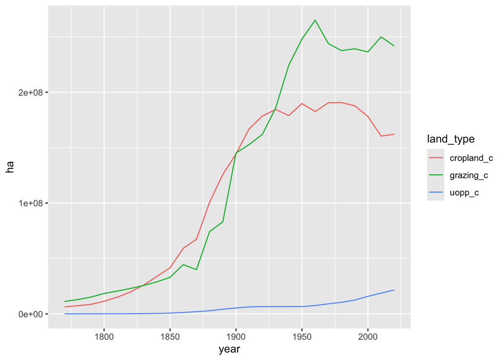

for each of these top food producing countries I want to look at which crops they are growing using [this data set](https://ourworldindata.org/grapher/land-area-per-crop-type?tab=table), and compare that to how much water the country is using from [this data set](https://ourworldindata.org/grapher/agricultural-water-as-a-share-of-total-water-withdrawals?tab=table) and/or carbon footprint from agriculture from [this data set](https://ourworldindata.org/grapher/ghg-emissions-by-sector?tab=table) to determine the sustainability of the countries agg industry.

I am aware that this is a very big project that I am proposing, and so I plan to use iterative code to streamline the process. Once I have the data visualized, I will be able to pick 2 countries that I want to actually tell the story about. This will most likely be any combination of the USA, Brazil, China, or India, and that will become clear once I explore the data fully through the methods described above.